# Module 19

#### Contrast SVE:

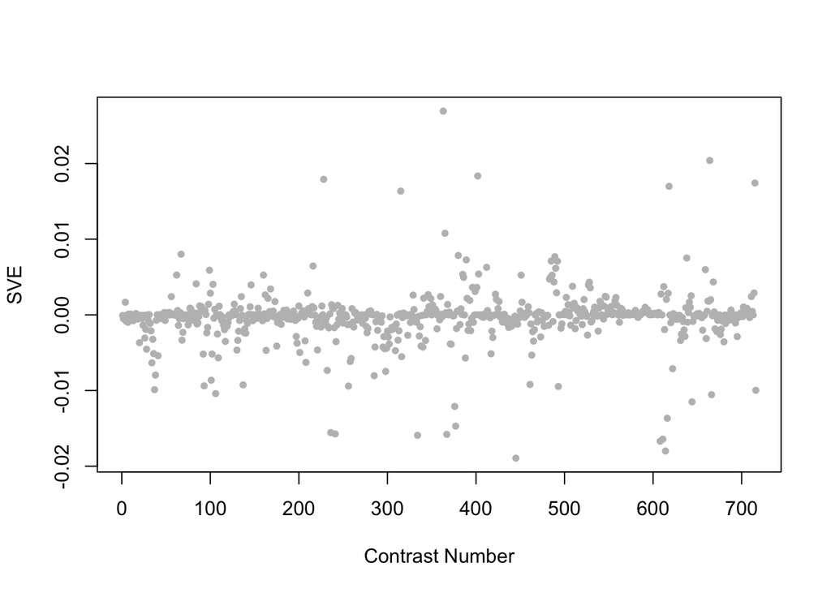

Positive SVE Contrasts:

|  | Contrast.Num | SVE | GEO.GSE | Cond.1 | Cond.2 | Mutation |
| --- | --- | --- | --- | --- | --- | --- |
| GSE36358.s2t1.vs.s0t1 | 363 | 0.03 | GSE36358 | Clino Rotation | Ground Control (Tsukuba space center) |  |
| GSE15159.s2t2.vs.s0t2 | 664 | 0.02 | GSE15159 | xpa-1_UV_2007_rep1 | N2_UV_2007_rep1 | xpa-1 |
| GSE30505.s1t2.vs.s2t2 | 402 | 0.02 | GSE30505 | Day 8 N2 (WT) E.V. #1 | Day 8 N2 (WT) ash-2 #1 | ash-2 |
| GSE42592B.s2t2.vs.s0t2 | 228 | 0.02 | GSE42592 | cadmium_mid_expose-4h_rep1 | cadmium_control_expose-4h_rep1 |  |
| GSE10787A.s1t1.vs.s0t1 | 715 | 0.02 | GSE10787 | Depomerai_heat_shock_1 | Depomerai_heat_control_1 |  |

Negative SVE Contrasts:

|  | Contrast.Num | SVE | GEO.GSE | Cond.1 | Cond.2 | Mutation |
| --- | --- | --- | --- | --- | --- | --- |
| GSE27677B.s0t9.vs.s0t7 | 445 | -0.02 | GSE27677 | N2, Fed 48 h, rep 1 | N2, Fed 24 h, rep 1 |  |
| GSE21591.s2t1.vs.s4t1 | 614 | -0.02 | GSE21591 | Input_1 | aMYC_1 |  |
| GSE21747.s1t1.vs.s0t1 | 608 | -0.02 | GSE21747 | albendazole exposure, biological rep 1 | no albendazole exposure, biological rep 1 |  |
| GSE21591.s2t1.vs.s5t1 | 611 | -0.02 | GSE21591 | Input_1 | aFLAG_1 |  |
| GSE38997.s4t2.vs.s1t2 | 334 | -0.02 | GSE38997 | experiment 4 UVC-exposed samples at 24 h 4u24 | experiment 4 control samples at 24 h 4c24 |  |

$~$

#### Contrast SVE, Up-Regulated Genes Only:

Calculating SVE for up-regulated and down-regulated genes separately may be more informative in many cases than projecting the up- and down- gene sets together. This is due to the fact that the weight distribution of many modules is highly skewed, indicating that only one of the hemi-modules may be biologically meaningful (i.e., a set of genes are strongly correlated by only a few genes (or none) are strongly anti-correlated to that set.)

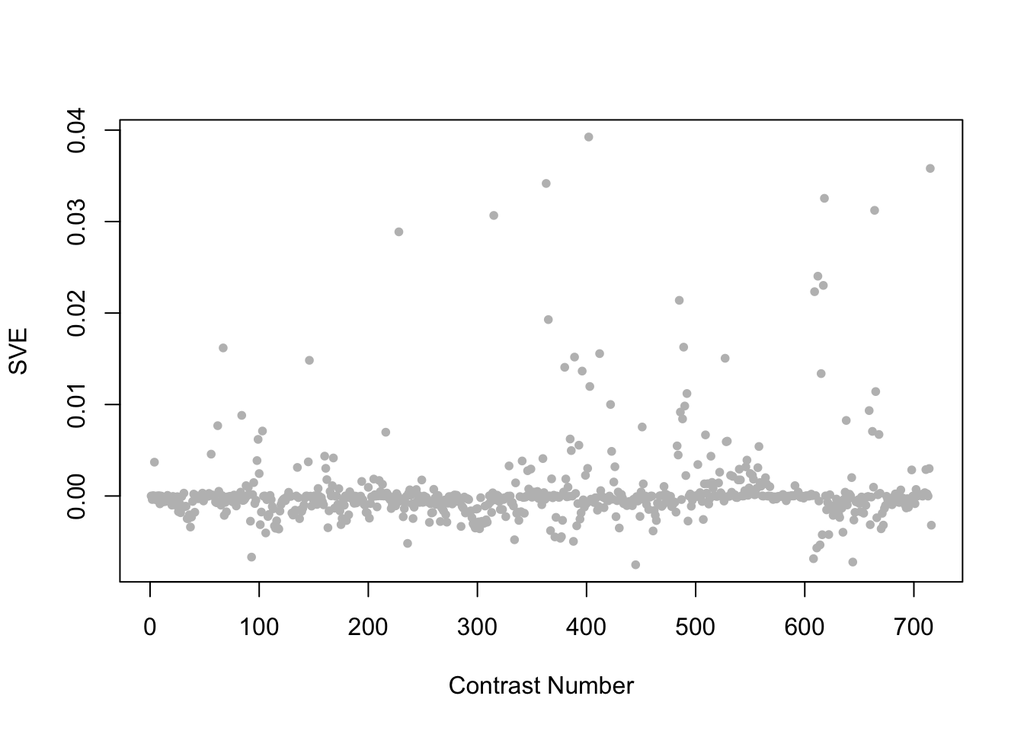

Positive SVE Contrasts:

|  | Contrast.Num | SVE | GEO.GSE | Cond.1 | Cond.2 | Mutation |
| --- | --- | --- | --- | --- | --- | --- |
| GSE30505.s1t2.vs.s2t2 | 402 | 0.04 | GSE30505 | Day 8 N2 (WT) E.V. #1 | Day 8 N2 (WT) ash-2 #1 | ash-2 |
| GSE10787A.s1t1.vs.s0t1 | 715 | 0.04 | GSE10787 | Depomerai_heat_shock_1 | Depomerai_heat_control_1 |  |
| GSE36358.s2t1.vs.s0t1 | 363 | 0.03 | GSE36358 | Clino Rotation | Ground Control (Tsukuba space center) |  |
| GSE21591.s1t1.vs.s2t1 | 618 | 0.03 | GSE21591 | N2_aFLAG_1 | Input_1 |  |
| GSE15159.s2t2.vs.s0t2 | 664 | 0.03 | GSE15159 | xpa-1_UV_2007_rep1 | N2_UV_2007_rep1 | xpa-1 |

Negative SVE Contrasts:

|  | Contrast.Num | SVE | GEO.GSE | Cond.1 | Cond.2 | Mutation |
| --- | --- | --- | --- | --- | --- | --- |
| GSE27677B.s0t9.vs.s0t7 | 445 | -0.01 | GSE27677 | N2, Fed 48 h, rep 1 | N2, Fed 24 h, rep 1 |  |
| GSE16915.s1t1.vs.s3t1 | 644 | -0.01 | GSE16915 | control sample | bio-electrosprayed sample |  |
| GSE21747.s1t1.vs.s0t1 | 608 | -0.01 | GSE21747 | albendazole exposure, biological rep 1 | no albendazole exposure, biological rep 1 |  |
| GSE5801.s3t1.vs.s1t1 | 93 | -0.01 | GSE5801 | daf2pmk1_RepA | daf2_RepA | pmk-1 |
| GSE21591.s2t1.vs.s5t1 | 611 | -0.01 | GSE21591 | Input_1 | aFLAG_1 |  |

$~$

#### Contrast SVE, Down-Regulated Genes Only:

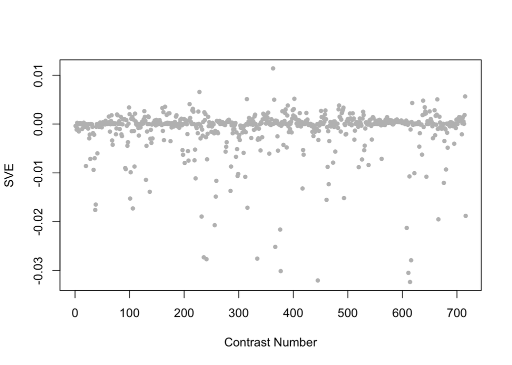

Positive SVE Contrasts:

|  | Contrast.Num | SVE | GEO.GSE | Cond.1 | Cond.2 | Mutation |
| --- | --- | --- | --- | --- | --- | --- |
| GSE36358.s2t1.vs.s0t1 | 363 | 0.01 | GSE36358 | Clino Rotation | Ground Control (Tsukuba space center) |  |
| GSE42592B.s2t2.vs.s0t2 | 228 | 0.01 | GSE42592 | cadmium_mid_expose-4h_rep1 | cadmium_control_expose-4h_rep1 |  |
| GSE10787A.s1t1.vs.s0t1 | 715 | 0.01 | GSE10787 | Depomerai_heat_shock_1 | Depomerai_heat_control_1 |  |
| GSE30505.s1t2.vs.s2t2 | 402 | 0.01 | GSE30505 | Day 8 N2 (WT) E.V. #1 | Day 8 N2 (WT) ash-2 #1 | ash-2 |
| GSE40127.s1t1.vs.s0t1 | 315 | 0.01 | GSE40127 | 1E_MK_Celegans_E_1 | 2c_MK_Celegans_Control_2 | gei-8 |

Negative SVE Contrasts:

|  | Contrast.Num | SVE | GEO.GSE | Cond.1 | Cond.2 | Mutation |
| --- | --- | --- | --- | --- | --- | --- |
| GSE21591.s2t1.vs.s4t1 | 614 | -0.03 | GSE21591 | Input_1 | aMYC_1 |  |
| GSE27677B.s0t9.vs.s0t7 | 445 | -0.03 | GSE27677 | N2, Fed 48 h, rep 1 | N2, Fed 24 h, rep 1 |  |
| GSE21591.s2t1.vs.s5t1 | 611 | -0.03 | GSE21591 | Input_1 | aFLAG_1 |  |
| GSE35354B.s1t3.vs.s1t1 | 377 | -0.03 | GSE35354 | TA200_rep1 | TA Control_rep1 |  |
| GSE21591.s2t1.vs.s3t1 | 616 | -0.03 | GSE21591 | Input_1 | GGF_aFLAG_1 |  |

$~$

$~$

#### GO Term Enrichment:

This analysis tests each hemi-module for enrichment of specific GO terms. Only gene-level annotations (e.g., as would be found on the gene’s page in Wormbase) are tested - the hierarchical structure of the GO ontology is not taken into account.

*Note: At least the top two most enriched terms from each GO domain (BP/MF/CC) are shown, even when not statistically significant.*

##### Enriched GO terms: Hemi-module A

| ID | GO.Term | GO Domain | Raw p-value | Adj p-value |
| --- | --- | --- | --- | --- |
| [GO_0009653](http://amigo.geneontology.org/amigo/term/GO:0009653) | anatomical structure morphogenesis | BP | 9.81e-04 | 9.90e-01 |
| [GO_1904491](http://amigo.geneontology.org/amigo/term/GO:1904491) | protein localization to ciliary transition zone | BP | 5.38e-03 | 9.90e-01 |
| [GO_0032422](http://amigo.geneontology.org/amigo/term/GO:0032422) | purine-rich negative regulatory element binding | MF | 1.59e-04 | 3.24e-01 |
| [GO_0001227](http://amigo.geneontology.org/amigo/term/GO:0001227) | DNA-binding transcription repressor activity, RNA polymerase II-specific | MF | 5.15e-04 | 5.26e-01 |
| [GO_0005737](http://amigo.geneontology.org/amigo/term/GO:0005737) | cytoplasm | CC | 2.72e-03 | 9.92e-01 |
| [GO_1990805](http://amigo.geneontology.org/amigo/term/GO:1990805) | central cylinder | CC | 1.26e-02 | 9.92e-01 |

##### Enriched GO terms: Hemi-module B

| ID | GO.Term | GO Domain | Raw p-value | Adj p-value |
| --- | --- | --- | --- | --- |
| [GO_0006082](http://amigo.geneontology.org/amigo/term/GO:0006082) | organic acid metabolic process | BP | 3.92e-07 | 5.81e-04 |
| [GO_0042738](http://amigo.geneontology.org/amigo/term/GO:0042738) | exogenous drug catabolic process | BP | 3.92e-07 | 5.81e-04 |
| [GO_0006805](http://amigo.geneontology.org/amigo/term/GO:0006805) | xenobiotic metabolic process | BP | 4.79e-07 | 5.81e-04 |
| [GO_0008395](http://amigo.geneontology.org/amigo/term/GO:0008395) | steroid hydroxylase activity | MF | 3.92e-07 | 4.43e-04 |
| [GO_0016712](http://amigo.geneontology.org/amigo/term/GO:0016712) | oxidoreductase activity, acting on paired donors, with incorporation or reduction of molecular oxygen, reduced flavin or flavoprotein as one donor, and incorporation of one atom of oxygen | MF | 4.33e-07 | 4.43e-04 |
| [GO_0016705](http://amigo.geneontology.org/amigo/term/GO:0016705) | oxidoreductase activity, acting on paired donors, with incorporation or reduction of molecular oxygen | MF | 6.51e-06 | 4.43e-03 |
| [GO_0004497](http://amigo.geneontology.org/amigo/term/GO:0004497) | monooxygenase activity | MF | 9.96e-06 | 5.09e-03 |
| [GO_0005506](http://amigo.geneontology.org/amigo/term/GO:0005506) | iron ion binding | MF | 2.48e-05 | 1.01e-02 |
| [GO_0020037](http://amigo.geneontology.org/amigo/term/GO:0020037) | heme binding | MF | 6.45e-05 | 2.20e-02 |
| [GO_0043231](http://amigo.geneontology.org/amigo/term/GO:0043231) | intracellular membrane-bounded organelle | CC | 7.77e-05 | 7.22e-02 |
| [GO_0016020](http://amigo.geneontology.org/amigo/term/GO:0016020) | membrane | CC | 2.88e-03 | 7.32e-01 |

$~$

$~$

#### Tissue Enrichment:

This analysis tests each hemi-module for enrichment of genes associated with anatomy terms. Negative enrichment scores indicate fewer hemi-module genes than expected by random chance were associated with the anatomy term in question.

##### Enriched tissues: Hemi-module A

No significant annotations.

##### Enriched tissues: Hemi-module B

No significant annotations.

$~$

$~$

#### HOMER promoter motif enrichment:

This analysis tests each hemi-module for enrichment of 108 known *C. elegans* transcription factor binding site motifs (see [108 CE motifs](https://katiepod.github.io//all.worm.motifs.html)) using the HOMER (Hypergeometric Optimization of Motif EnRichment) software (see [PMID:20513432](https://pubmed.ncbi.nlm.nih.gov/20513432)). HOMER was run using default parameters on sequences 1 kb upstream of the transcription start site.

##### Motif enrichment: Hemi-module A

Total target sequences = 234  
Total background sequences = 41203  
* - possible false positive

Rank

Motif

P-value

log P-pvalue

% of Targets

% of Background

STD(Bg STD)

Best Match/Details

Motif File

1 *

[figure not shown]

1e-10

-2.477e+01

6.84%

0.68%

246.1bp (331.7bp)

fkh-9/MA1440.1/Jaspar(0.514)  
[More Information](https://katiepod.github.io/HomerResults/m19_a_hemi_genes.txt.out.1kb/homerResults/motif1.info.html) | [Similar Motifs Found](https://katiepod.github.io/HomerResults/m19_a_hemi_genes.txt.out.1kb/homerResults/motif1.similar.html)

[motif file (matrix)](https://katiepod.github.io/HomerResults/m19_a_hemi_genes.txt.out.1kb/homerResults/motif1.motif)

2 *

[figure not shown]

1e-9

-2.274e+01

9.83%

1.83%

287.3bp (301.7bp)

LIN-39(Homeobox)/cElegans.L3-LIN39-ChIP-Seq(modEncode)/Homer(0.697)  
[More Information](https://katiepod.github.io/HomerResults/m19_a_hemi_genes.txt.out.1kb/homerResults/motif2.info.html) | [Similar Motifs Found](https://katiepod.github.io/HomerResults/m19_a_hemi_genes.txt.out.1kb/homerResults/motif2.similar.html)

[motif file (matrix)](https://katiepod.github.io/HomerResults/m19_a_hemi_genes.txt.out.1kb/homerResults/motif2.motif)

3 *

[figure not shown]

1e-9

-2.098e+01

5.13%

0.42%

273.7bp (318.2bp)

POL010.1_DCE_S_III/Jaspar(0.524)  
[More Information](https://katiepod.github.io/HomerResults/m19_a_hemi_genes.txt.out.1kb/homerResults/motif3.info.html) | [Similar Motifs Found](https://katiepod.github.io/HomerResults/m19_a_hemi_genes.txt.out.1kb/homerResults/motif3.similar.html)

[motif file (matrix)](https://katiepod.github.io/HomerResults/m19_a_hemi_genes.txt.out.1kb/homerResults/motif3.motif)

4 *

[figure not shown]

1e-8

-2.031e+01

3.42%

0.12%

310.4bp (291.1bp)

unc-30/MA1443.1/Jaspar(0.542)  
[More Information](https://katiepod.github.io/HomerResults/m19_a_hemi_genes.txt.out.1kb/homerResults/motif4.info.html) | [Similar Motifs Found](https://katiepod.github.io/HomerResults/m19_a_hemi_genes.txt.out.1kb/homerResults/motif4.similar.html)

[motif file (matrix)](https://katiepod.github.io/HomerResults/m19_a_hemi_genes.txt.out.1kb/homerResults/motif4.motif)

5 *

[figure not shown]

1e-8

-2.010e+01

5.98%

0.69%

303.5bp (312.4bp)

POL010.1_DCE_S_III/Jaspar(0.565)  
[More Information](https://katiepod.github.io/HomerResults/m19_a_hemi_genes.txt.out.1kb/homerResults/motif5.info.html) | [Similar Motifs Found](https://katiepod.github.io/HomerResults/m19_a_hemi_genes.txt.out.1kb/homerResults/motif5.similar.html)

[motif file (matrix)](https://katiepod.github.io/HomerResults/m19_a_hemi_genes.txt.out.1kb/homerResults/motif5.motif)

6 *

[figure not shown]

1e-8

-1.943e+01

6.84%

1.00%

302.6bp (314.4bp)

fos-1/MA1448.1/Jaspar(0.639)  
[More Information](https://katiepod.github.io/HomerResults/m19_a_hemi_genes.txt.out.1kb/homerResults/motif6.info.html) | [Similar Motifs Found](https://katiepod.github.io/HomerResults/m19_a_hemi_genes.txt.out.1kb/homerResults/motif6.similar.html)

[motif file (matrix)](https://katiepod.github.io/HomerResults/m19_a_hemi_genes.txt.out.1kb/homerResults/motif6.motif)

7 *

[figure not shown]

1e-8

-1.928e+01

8.12%

1.48%

303.5bp (330.8bp)

PHA-4(Forkhead)/cElegans-Embryos-PHA4-ChIP-Seq(modEncode)/Homer(0.601)  
[More Information](https://katiepod.github.io/HomerResults/m19_a_hemi_genes.txt.out.1kb/homerResults/motif7.info.html) | [Similar Motifs Found](https://katiepod.github.io/HomerResults/m19_a_hemi_genes.txt.out.1kb/homerResults/motif7.similar.html)

[motif file (matrix)](https://katiepod.github.io/HomerResults/m19_a_hemi_genes.txt.out.1kb/homerResults/motif7.motif)

8 *

[figure not shown]

1e-8

-1.926e+01

2.99%

0.09%

188.4bp (282.0bp)

nhr-6/MA1451.1/Jaspar(0.674)  
[More Information](https://katiepod.github.io/HomerResults/m19_a_hemi_genes.txt.out.1kb/homerResults/motif8.info.html) | [Similar Motifs Found](https://katiepod.github.io/HomerResults/m19_a_hemi_genes.txt.out.1kb/homerResults/motif8.similar.html)

[motif file (matrix)](https://katiepod.github.io/HomerResults/m19_a_hemi_genes.txt.out.1kb/homerResults/motif8.motif)

9 *

[figure not shown]

1e-8

-1.877e+01

4.70%

0.41%

250.5bp (290.1bp)

POL009.1_DCE_S_II/Jaspar(0.475)  
[More Information](https://katiepod.github.io/HomerResults/m19_a_hemi_genes.txt.out.1kb/homerResults/motif9.info.html) | [Similar Motifs Found](https://katiepod.github.io/HomerResults/m19_a_hemi_genes.txt.out.1kb/homerResults/motif9.similar.html)

[motif file (matrix)](https://katiepod.github.io/HomerResults/m19_a_hemi_genes.txt.out.1kb/homerResults/motif9.motif)

10 *

[figure not shown]

1e-8

-1.858e+01

19.66%

7.86%

271.0bp (314.8bp)

che-1/MA0260.1/Jaspar(0.614)  
[More Information](https://katiepod.github.io/HomerResults/m19_a_hemi_genes.txt.out.1kb/homerResults/motif10.info.html) | [Similar Motifs Found](https://katiepod.github.io/HomerResults/m19_a_hemi_genes.txt.out.1kb/homerResults/motif10.similar.html)

[motif file (matrix)](https://katiepod.github.io/HomerResults/m19_a_hemi_genes.txt.out.1kb/homerResults/motif10.motif)

11 *

[figure not shown]

1e-7

-1.805e+01

4.70%

0.44%

281.6bp (318.1bp)

fkh-9/MA1440.1/Jaspar(0.618)  
[More Information](https://katiepod.github.io/HomerResults/m19_a_hemi_genes.txt.out.1kb/homerResults/motif11.info.html) | [Similar Motifs Found](https://katiepod.github.io/HomerResults/m19_a_hemi_genes.txt.out.1kb/homerResults/motif11.similar.html)

[motif file (matrix)](https://katiepod.github.io/HomerResults/m19_a_hemi_genes.txt.out.1kb/homerResults/motif11.motif)

12 *

[figure not shown]

1e-7

-1.794e+01

6.41%

0.96%

234.5bp (307.5bp)

MF0001.1_ETS_class/Jaspar(0.579)  
[More Information](https://katiepod.github.io/HomerResults/m19_a_hemi_genes.txt.out.1kb/homerResults/motif12.info.html) | [Similar Motifs Found](https://katiepod.github.io/HomerResults/m19_a_hemi_genes.txt.out.1kb/homerResults/motif12.similar.html)

[motif file (matrix)](https://katiepod.github.io/HomerResults/m19_a_hemi_genes.txt.out.1kb/homerResults/motif12.motif)

13 *

[figure not shown]

1e-7

-1.787e+01

2.99%

0.11%

167.4bp (293.8bp)

POL012.1_TATA-Box/Jaspar(0.607)  
[More Information](https://katiepod.github.io/HomerResults/m19_a_hemi_genes.txt.out.1kb/homerResults/motif13.info.html) | [Similar Motifs Found](https://katiepod.github.io/HomerResults/m19_a_hemi_genes.txt.out.1kb/homerResults/motif13.similar.html)

[motif file (matrix)](https://katiepod.github.io/HomerResults/m19_a_hemi_genes.txt.out.1kb/homerResults/motif13.motif)

14 *

[figure not shown]

1e-7

-1.787e+01

2.99%

0.11%

279.4bp (265.7bp)

sma-4/MA0925.1/Jaspar(0.542)  
[More Information](https://katiepod.github.io/HomerResults/m19_a_hemi_genes.txt.out.1kb/homerResults/motif14.info.html) | [Similar Motifs Found](https://katiepod.github.io/HomerResults/m19_a_hemi_genes.txt.out.1kb/homerResults/motif14.similar.html)

[motif file (matrix)](https://katiepod.github.io/HomerResults/m19_a_hemi_genes.txt.out.1kb/homerResults/motif14.motif)

15 *

[figure not shown]

1e-7

-1.755e+01

3.42%

0.18%

187.5bp (290.6bp)

pqm-1/MA1703.1/Jaspar(0.571)  
[More Information](https://katiepod.github.io/HomerResults/m19_a_hemi_genes.txt.out.1kb/homerResults/motif15.info.html) | [Similar Motifs Found](https://katiepod.github.io/HomerResults/m19_a_hemi_genes.txt.out.1kb/homerResults/motif15.similar.html)

[motif file (matrix)](https://katiepod.github.io/HomerResults/m19_a_hemi_genes.txt.out.1kb/homerResults/motif15.motif)

16 *

[figure not shown]

1e-7

-1.748e+01

4.70%

0.47%

271.2bp (313.9bp)

pal-1/MA0924.1/Jaspar(0.723)  
[More Information](https://katiepod.github.io/HomerResults/m19_a_hemi_genes.txt.out.1kb/homerResults/motif16.info.html) | [Similar Motifs Found](https://katiepod.github.io/HomerResults/m19_a_hemi_genes.txt.out.1kb/homerResults/motif16.similar.html)

[motif file (matrix)](https://katiepod.github.io/HomerResults/m19_a_hemi_genes.txt.out.1kb/homerResults/motif16.motif)

17 *

[figure not shown]

1e-7

-1.707e+01

16.24%

6.07%

311.7bp (310.2bp)

snpc-4/MA0544.1/Jaspar(0.546)  
[More Information](https://katiepod.github.io/HomerResults/m19_a_hemi_genes.txt.out.1kb/homerResults/motif17.info.html) | [Similar Motifs Found](https://katiepod.github.io/HomerResults/m19_a_hemi_genes.txt.out.1kb/homerResults/motif17.similar.html)

[motif file (matrix)](https://katiepod.github.io/HomerResults/m19_a_hemi_genes.txt.out.1kb/homerResults/motif17.motif)

18 *

[figure not shown]

1e-7

-1.692e+01

10.68%

2.94%

273.8bp (304.8bp)

ces-2/MA0922.1/Jaspar(0.648)  
[More Information](https://katiepod.github.io/HomerResults/m19_a_hemi_genes.txt.out.1kb/homerResults/motif18.info.html) | [Similar Motifs Found](https://katiepod.github.io/HomerResults/m19_a_hemi_genes.txt.out.1kb/homerResults/motif18.similar.html)

[motif file (matrix)](https://katiepod.github.io/HomerResults/m19_a_hemi_genes.txt.out.1kb/homerResults/motif18.motif)

19 *

[figure not shown]

1e-7

-1.676e+01

8.12%

1.75%

282.7bp (292.9bp)

cebp-1/MA1444.1/Jaspar(0.730)  
[More Information](https://katiepod.github.io/HomerResults/m19_a_hemi_genes.txt.out.1kb/homerResults/motif19.info.html) | [Similar Motifs Found](https://katiepod.github.io/HomerResults/m19_a_hemi_genes.txt.out.1kb/homerResults/motif19.similar.html)

[motif file (matrix)](https://katiepod.github.io/HomerResults/m19_a_hemi_genes.txt.out.1kb/homerResults/motif19.motif)

20 *

[figure not shown]

1e-7

-1.664e+01

8.55%

1.95%

284.9bp (323.0bp)

ceh-22/MA0264.1/Jaspar(0.543)  
[More Information](https://katiepod.github.io/HomerResults/m19_a_hemi_genes.txt.out.1kb/homerResults/motif20.info.html) | [Similar Motifs Found](https://katiepod.github.io/HomerResults/m19_a_hemi_genes.txt.out.1kb/homerResults/motif20.similar.html)

[motif file (matrix)](https://katiepod.github.io/HomerResults/m19_a_hemi_genes.txt.out.1kb/homerResults/motif20.motif)

21 *

[figure not shown]

1e-7

-1.655e+01

4.27%

0.40%

291.8bp (304.3bp)

POL010.1_DCE_S_III/Jaspar(0.529)  
[More Information](https://katiepod.github.io/HomerResults/m19_a_hemi_genes.txt.out.1kb/homerResults/motif21.info.html) | [Similar Motifs Found](https://katiepod.github.io/HomerResults/m19_a_hemi_genes.txt.out.1kb/homerResults/motif21.similar.html)

[motif file (matrix)](https://katiepod.github.io/HomerResults/m19_a_hemi_genes.txt.out.1kb/homerResults/motif21.motif)

22 *

[figure not shown]

1e-7

-1.652e+01

4.70%

0.52%

262.0bp (283.7bp)

ceh-38/MA1699.1/Jaspar(0.650)  
[More Information](https://katiepod.github.io/HomerResults/m19_a_hemi_genes.txt.out.1kb/homerResults/motif22.info.html) | [Similar Motifs Found](https://katiepod.github.io/HomerResults/m19_a_hemi_genes.txt.out.1kb/homerResults/motif22.similar.html)

[motif file (matrix)](https://katiepod.github.io/HomerResults/m19_a_hemi_genes.txt.out.1kb/homerResults/motif22.motif)

23 *

[figure not shown]

1e-6

-1.610e+01

5.13%

0.67%

192.4bp (305.1bp)

ceh-22/MA0264.1/Jaspar(0.591)  
[More Information](https://katiepod.github.io/HomerResults/m19_a_hemi_genes.txt.out.1kb/homerResults/motif23.info.html) | [Similar Motifs Found](https://katiepod.github.io/HomerResults/m19_a_hemi_genes.txt.out.1kb/homerResults/motif23.similar.html)

[motif file (matrix)](https://katiepod.github.io/HomerResults/m19_a_hemi_genes.txt.out.1kb/homerResults/motif23.motif)

24 *

[figure not shown]

1e-6

-1.576e+01

15.38%

5.86%

293.7bp (329.1bp)

POL004.1_CCAAT-box/Jaspar(0.479)  
[More Information](https://katiepod.github.io/HomerResults/m19_a_hemi_genes.txt.out.1kb/homerResults/motif24.info.html) | [Similar Motifs Found](https://katiepod.github.io/HomerResults/m19_a_hemi_genes.txt.out.1kb/homerResults/motif24.similar.html)

[motif file (matrix)](https://katiepod.github.io/HomerResults/m19_a_hemi_genes.txt.out.1kb/homerResults/motif24.motif)

25 *

[figure not shown]

1e-6

-1.560e+01

18.38%

7.84%

271.7bp (299.4bp)

dsc-1/MA0919.1/Jaspar(0.559)  
[More Information](https://katiepod.github.io/HomerResults/m19_a_hemi_genes.txt.out.1kb/homerResults/motif25.info.html) | [Similar Motifs Found](https://katiepod.github.io/HomerResults/m19_a_hemi_genes.txt.out.1kb/homerResults/motif25.similar.html)

[motif file (matrix)](https://katiepod.github.io/HomerResults/m19_a_hemi_genes.txt.out.1kb/homerResults/motif25.motif)

26 *

[figure not shown]

1e-6

-1.556e+01

1.28%

0.00%

229.1bp (0.0bp)

SD0003.1_at_AC_acceptor/Jaspar(0.498)  
[More Information](https://katiepod.github.io/HomerResults/m19_a_hemi_genes.txt.out.1kb/homerResults/motif26.info.html) | [Similar Motifs Found](https://katiepod.github.io/HomerResults/m19_a_hemi_genes.txt.out.1kb/homerResults/motif26.similar.html)

[motif file (matrix)](https://katiepod.github.io/HomerResults/m19_a_hemi_genes.txt.out.1kb/homerResults/motif26.motif)

27 *

[figure not shown]

1e-6

-1.555e+01

3.42%

0.24%

208.9bp (271.5bp)

lin-14/MA0261.1/Jaspar(0.625)  
[More Information](https://katiepod.github.io/HomerResults/m19_a_hemi_genes.txt.out.1kb/homerResults/motif27.info.html) | [Similar Motifs Found](https://katiepod.github.io/HomerResults/m19_a_hemi_genes.txt.out.1kb/homerResults/motif27.similar.html)

[motif file (matrix)](https://katiepod.github.io/HomerResults/m19_a_hemi_genes.txt.out.1kb/homerResults/motif27.motif)

28 *

[figure not shown]

1e-6

-1.511e+01

3.85%

0.36%

266.3bp (287.2bp)

PL0004.1_hlh-27/Jaspar(0.626)  
[More Information](https://katiepod.github.io/HomerResults/m19_a_hemi_genes.txt.out.1kb/homerResults/motif28.info.html) | [Similar Motifs Found](https://katiepod.github.io/HomerResults/m19_a_hemi_genes.txt.out.1kb/homerResults/motif28.similar.html)

[motif file (matrix)](https://katiepod.github.io/HomerResults/m19_a_hemi_genes.txt.out.1kb/homerResults/motif28.motif)

29 *

[figure not shown]

1e-6

-1.469e+01

8.12%

2.01%

281.1bp (313.1bp)

sma-4/MA0925.1/Jaspar(0.533)  
[More Information](https://katiepod.github.io/HomerResults/m19_a_hemi_genes.txt.out.1kb/homerResults/motif29.info.html) | [Similar Motifs Found](https://katiepod.github.io/HomerResults/m19_a_hemi_genes.txt.out.1kb/homerResults/motif29.similar.html)

[motif file (matrix)](https://katiepod.github.io/HomerResults/m19_a_hemi_genes.txt.out.1kb/homerResults/motif29.motif)

30 *

[figure not shown]

1e-5

-1.325e+01

2.99%

0.23%

228.5bp (283.7bp)

PL0012.1_hlh-2::hlh-8/Jaspar(0.477)  
[More Information](https://katiepod.github.io/HomerResults/m19_a_hemi_genes.txt.out.1kb/homerResults/motif30.info.html) | [Similar Motifs Found](https://katiepod.github.io/HomerResults/m19_a_hemi_genes.txt.out.1kb/homerResults/motif30.similar.html)

[motif file (matrix)](https://katiepod.github.io/HomerResults/m19_a_hemi_genes.txt.out.1kb/homerResults/motif30.motif)

31 *

[figure not shown]

1e-5

-1.290e+01

8.12%

2.27%

304.9bp (301.4bp)

POL012.1_TATA-Box/Jaspar(0.574)  
[More Information](https://katiepod.github.io/HomerResults/m19_a_hemi_genes.txt.out.1kb/homerResults/motif31.info.html) | [Similar Motifs Found](https://katiepod.github.io/HomerResults/m19_a_hemi_genes.txt.out.1kb/homerResults/motif31.similar.html)

[motif file (matrix)](https://katiepod.github.io/HomerResults/m19_a_hemi_genes.txt.out.1kb/homerResults/motif31.motif)

32 *

[figure not shown]

1e-5

-1.194e+01

17.09%

8.11%

295.1bp (314.4bp)

PHA-4(Forkhead)/cElegans-Embryos-PHA4-ChIP-Seq(modEncode)/Homer(0.775)  
[More Information](https://katiepod.github.io/HomerResults/m19_a_hemi_genes.txt.out.1kb/homerResults/motif32.info.html) | [Similar Motifs Found](https://katiepod.github.io/HomerResults/m19_a_hemi_genes.txt.out.1kb/homerResults/motif32.similar.html)

[motif file (matrix)](https://katiepod.github.io/HomerResults/m19_a_hemi_genes.txt.out.1kb/homerResults/motif32.motif)

33 *

[figure not shown]

1e-5

-1.191e+01

5.13%

1.01%

272.7bp (314.4bp)

MF0009.1_TRP(MYB)_class/Jaspar(0.634)  
[More Information](https://katiepod.github.io/HomerResults/m19_a_hemi_genes.txt.out.1kb/homerResults/motif33.info.html) | [Similar Motifs Found](https://katiepod.github.io/HomerResults/m19_a_hemi_genes.txt.out.1kb/homerResults/motif33.similar.html)

[motif file (matrix)](https://katiepod.github.io/HomerResults/m19_a_hemi_genes.txt.out.1kb/homerResults/motif33.motif)

34 *

[figure not shown]

1e-4

-1.142e+01

12.82%

5.36%

289.9bp (292.8bp)

MF0009.1_TRP(MYB)_class/Jaspar(0.584)  
[More Information](https://katiepod.github.io/HomerResults/m19_a_hemi_genes.txt.out.1kb/homerResults/motif34.info.html) | [Similar Motifs Found](https://katiepod.github.io/HomerResults/m19_a_hemi_genes.txt.out.1kb/homerResults/motif34.similar.html)

[motif file (matrix)](https://katiepod.github.io/HomerResults/m19_a_hemi_genes.txt.out.1kb/homerResults/motif34.motif)

35 *

[figure not shown]

1e-4

-1.054e+01

2.14%

0.14%

203.6bp (346.9bp)

che-1/MA0260.1/Jaspar(0.521)  
[More Information](https://katiepod.github.io/HomerResults/m19_a_hemi_genes.txt.out.1kb/homerResults/motif35.info.html) | [Similar Motifs Found](https://katiepod.github.io/HomerResults/m19_a_hemi_genes.txt.out.1kb/homerResults/motif35.similar.html)

[motif file (matrix)](https://katiepod.github.io/HomerResults/m19_a_hemi_genes.txt.out.1kb/homerResults/motif35.motif)

36 *

[figure not shown]

1e-4

-9.300e+00

8.97%

3.49%

232.4bp (288.8bp)

MF0011.1_HMG_class/Jaspar(0.685)  
[More Information](https://katiepod.github.io/HomerResults/m19_a_hemi_genes.txt.out.1kb/homerResults/motif36.info.html) | [Similar Motifs Found](https://katiepod.github.io/HomerResults/m19_a_hemi_genes.txt.out.1kb/homerResults/motif36.similar.html)

[motif file (matrix)](https://katiepod.github.io/HomerResults/m19_a_hemi_genes.txt.out.1kb/homerResults/motif36.motif)

37 *

[figure not shown]

1e-4

-9.276e+00

0.85%

0.00%

75.9bp (0.0bp)

ceh-22/MA0264.1/Jaspar(0.542)  
[More Information](https://katiepod.github.io/HomerResults/m19_a_hemi_genes.txt.out.1kb/homerResults/motif37.info.html) | [Similar Motifs Found](https://katiepod.github.io/HomerResults/m19_a_hemi_genes.txt.out.1kb/homerResults/motif37.similar.html)

[motif file (matrix)](https://katiepod.github.io/HomerResults/m19_a_hemi_genes.txt.out.1kb/homerResults/motif37.motif)

38 *

[figure not shown]

1e-3

-8.358e+00

8.97%

3.74%

297.1bp (299.7bp)

SD0003.1_at_AC_acceptor/Jaspar(0.571)  
[More Information](https://katiepod.github.io/HomerResults/m19_a_hemi_genes.txt.out.1kb/homerResults/motif38.info.html) | [Similar Motifs Found](https://katiepod.github.io/HomerResults/m19_a_hemi_genes.txt.out.1kb/homerResults/motif38.similar.html)

[motif file (matrix)](https://katiepod.github.io/HomerResults/m19_a_hemi_genes.txt.out.1kb/homerResults/motif38.motif)

39 *

[figure not shown]

1e-3

-8.036e+00

1.28%

0.05%

226.0bp (308.7bp)

PL0016.1_ref-1/Jaspar(0.496)  
[More Information](https://katiepod.github.io/HomerResults/m19_a_hemi_genes.txt.out.1kb/homerResults/motif39.info.html) | [Similar Motifs Found](https://katiepod.github.io/HomerResults/m19_a_hemi_genes.txt.out.1kb/homerResults/motif39.similar.html)

[motif file (matrix)](https://katiepod.github.io/HomerResults/m19_a_hemi_genes.txt.out.1kb/homerResults/motif39.motif)

40 *

[figure not shown]

1e-3

-7.677e+00

0.85%

0.01%

153.0bp (114.3bp)

MF0004.1_Nuclear_Receptor_class/Jaspar(0.659)  
[More Information](https://katiepod.github.io/HomerResults/m19_a_hemi_genes.txt.out.1kb/homerResults/motif40.info.html) | [Similar Motifs Found](https://katiepod.github.io/HomerResults/m19_a_hemi_genes.txt.out.1kb/homerResults/motif40.similar.html)

[motif file (matrix)](https://katiepod.github.io/HomerResults/m19_a_hemi_genes.txt.out.1kb/homerResults/motif40.motif)

41 *

[figure not shown]

1e-3

-7.571e+00

1.28%

0.06%

283.5bp (346.4bp)

efl-1/MA0541.1/Jaspar(0.530)  
[More Information](https://katiepod.github.io/HomerResults/m19_a_hemi_genes.txt.out.1kb/homerResults/motif41.info.html) | [Similar Motifs Found](https://katiepod.github.io/HomerResults/m19_a_hemi_genes.txt.out.1kb/homerResults/motif41.similar.html)

[motif file (matrix)](https://katiepod.github.io/HomerResults/m19_a_hemi_genes.txt.out.1kb/homerResults/motif41.motif)

##### Motif enrichment: Hemi-module B

Total target sequences = 22  
Total background sequences = 36672  
* - possible false positive

Rank

Motif

P-value

log P-pvalue

% of Targets

% of Background

STD(Bg STD)

Best Match/Details

Motif File

1 *

[figure not shown]

1e-9

-2.276e+01

18.18%

0.03%

241.3bp (404.0bp)

POL012.1_TATA-Box/Jaspar(0.546)  
[More Information](https://katiepod.github.io/HomerResults/m19_b_hemi_genes.txt.out.1kb/homerResults/motif1.info.html) | [Similar Motifs Found](https://katiepod.github.io/HomerResults/m19_b_hemi_genes.txt.out.1kb/homerResults/motif1.similar.html)

[motif file (matrix)](https://katiepod.github.io/HomerResults/m19_b_hemi_genes.txt.out.1kb/homerResults/motif1.motif)

2 *

[figure not shown]

1e-7

-1.787e+01

31.82%

1.42%

217.9bp (320.7bp)

SD0002.1_at_AC_acceptor/Jaspar(0.562)  
[More Information](https://katiepod.github.io/HomerResults/m19_b_hemi_genes.txt.out.1kb/homerResults/motif2.info.html) | [Similar Motifs Found](https://katiepod.github.io/HomerResults/m19_b_hemi_genes.txt.out.1kb/homerResults/motif2.similar.html)

[motif file (matrix)](https://katiepod.github.io/HomerResults/m19_b_hemi_genes.txt.out.1kb/homerResults/motif2.motif)

3 *

[figure not shown]

1e-7

-1.689e+01

27.27%

0.94%

276.7bp (345.0bp)

MF0010.1_Homeobox_class/Jaspar(0.588)  
[More Information](https://katiepod.github.io/HomerResults/m19_b_hemi_genes.txt.out.1kb/homerResults/motif3.info.html) | [Similar Motifs Found](https://katiepod.github.io/HomerResults/m19_b_hemi_genes.txt.out.1kb/homerResults/motif3.similar.html)

[motif file (matrix)](https://katiepod.github.io/HomerResults/m19_b_hemi_genes.txt.out.1kb/homerResults/motif3.motif)

4 *

[figure not shown]

1e-7

-1.629e+01

13.64%

0.03%

201.5bp (238.4bp)

PL0017.1_hlh-2::hlh-10/Jaspar(0.651)  
[More Information](https://katiepod.github.io/HomerResults/m19_b_hemi_genes.txt.out.1kb/homerResults/motif4.info.html) | [Similar Motifs Found](https://katiepod.github.io/HomerResults/m19_b_hemi_genes.txt.out.1kb/homerResults/motif4.similar.html)

[motif file (matrix)](https://katiepod.github.io/HomerResults/m19_b_hemi_genes.txt.out.1kb/homerResults/motif4.motif)

5 *

[figure not shown]

1e-6

-1.578e+01

40.91%

4.25%

163.1bp (331.3bp)

mab-5/MA1442.1/Jaspar(0.658)  
[More Information](https://katiepod.github.io/HomerResults/m19_b_hemi_genes.txt.out.1kb/homerResults/motif5.info.html) | [Similar Motifs Found](https://katiepod.github.io/HomerResults/m19_b_hemi_genes.txt.out.1kb/homerResults/motif5.similar.html)

[motif file (matrix)](https://katiepod.github.io/HomerResults/m19_b_hemi_genes.txt.out.1kb/homerResults/motif5.motif)

6 *

[figure not shown]

1e-6

-1.522e+01

13.64%

0.05%

69.5bp (342.5bp)

POL013.1_MED-1/Jaspar(0.507)  
[More Information](https://katiepod.github.io/HomerResults/m19_b_hemi_genes.txt.out.1kb/homerResults/motif6.info.html) | [Similar Motifs Found](https://katiepod.github.io/HomerResults/m19_b_hemi_genes.txt.out.1kb/homerResults/motif6.similar.html)

[motif file (matrix)](https://katiepod.github.io/HomerResults/m19_b_hemi_genes.txt.out.1kb/homerResults/motif6.motif)

7 *

[figure not shown]

1e-6

-1.489e+01

9.09%

0.00%

243.0bp (0.0bp)

sma-4/MA0925.1/Jaspar(0.565)  
[More Information](https://katiepod.github.io/HomerResults/m19_b_hemi_genes.txt.out.1kb/homerResults/motif7.info.html) | [Similar Motifs Found](https://katiepod.github.io/HomerResults/m19_b_hemi_genes.txt.out.1kb/homerResults/motif7.similar.html)

[motif file (matrix)](https://katiepod.github.io/HomerResults/m19_b_hemi_genes.txt.out.1kb/homerResults/motif7.motif)

8 *

[figure not shown]

1e-6

-1.409e+01

31.82%

2.50%

246.6bp (335.7bp)

MF0009.1_TRP(MYB)_class/Jaspar(0.698)  
[More Information](https://katiepod.github.io/HomerResults/m19_b_hemi_genes.txt.out.1kb/homerResults/motif8.info.html) | [Similar Motifs Found](https://katiepod.github.io/HomerResults/m19_b_hemi_genes.txt.out.1kb/homerResults/motif8.similar.html)

[motif file (matrix)](https://katiepod.github.io/HomerResults/m19_b_hemi_genes.txt.out.1kb/homerResults/motif8.motif)

9 *

[figure not shown]

1e-5

-1.259e+01

9.09%

0.01%

78.0bp (188.7bp)

SA0002.1_at_AC_acceptor/Jaspar(0.508)  
[More Information](https://katiepod.github.io/HomerResults/m19_b_hemi_genes.txt.out.1kb/homerResults/motif9.info.html) | [Similar Motifs Found](https://katiepod.github.io/HomerResults/m19_b_hemi_genes.txt.out.1kb/homerResults/motif9.similar.html)

[motif file (matrix)](https://katiepod.github.io/HomerResults/m19_b_hemi_genes.txt.out.1kb/homerResults/motif9.motif)

10 *

[figure not shown]

1e-5

-1.238e+01

36.36%

4.69%

256.9bp (329.7bp)

lin-54/MA1450.1/Jaspar(0.743)  
[More Information](https://katiepod.github.io/HomerResults/m19_b_hemi_genes.txt.out.1kb/homerResults/motif10.info.html) | [Similar Motifs Found](https://katiepod.github.io/HomerResults/m19_b_hemi_genes.txt.out.1kb/homerResults/motif10.similar.html)

[motif file (matrix)](https://katiepod.github.io/HomerResults/m19_b_hemi_genes.txt.out.1kb/homerResults/motif10.motif)

11 *

[figure not shown]

1e-5

-1.174e+01

18.18%

0.58%

225.2bp (306.6bp)

ceh-10::ttx-3/MA0263.1/Jaspar(0.565)  
[More Information](https://katiepod.github.io/HomerResults/m19_b_hemi_genes.txt.out.1kb/homerResults/motif11.info.html) | [Similar Motifs Found](https://katiepod.github.io/HomerResults/m19_b_hemi_genes.txt.out.1kb/homerResults/motif11.similar.html)

[motif file (matrix)](https://katiepod.github.io/HomerResults/m19_b_hemi_genes.txt.out.1kb/homerResults/motif11.motif)

12 *

[figure not shown]

1e-4

-9.753e+00

9.09%

0.05%

263.0bp (380.6bp)

PL0012.1_hlh-2::hlh-8/Jaspar(0.570)  
[More Information](https://katiepod.github.io/HomerResults/m19_b_hemi_genes.txt.out.1kb/homerResults/motif12.info.html) | [Similar Motifs Found](https://katiepod.github.io/HomerResults/m19_b_hemi_genes.txt.out.1kb/homerResults/motif12.similar.html)

[motif file (matrix)](https://katiepod.github.io/HomerResults/m19_b_hemi_genes.txt.out.1kb/homerResults/motif12.motif)

13 *

[figure not shown]

1e-3

-8.334e+00

13.64%

0.55%

71.9bp (323.3bp)

unc-62/MA0918.1/Jaspar(0.625)  
[More Information](https://katiepod.github.io/HomerResults/m19_b_hemi_genes.txt.out.1kb/homerResults/motif13.info.html) | [Similar Motifs Found](https://katiepod.github.io/HomerResults/m19_b_hemi_genes.txt.out.1kb/homerResults/motif13.similar.html)

[motif file (matrix)](https://katiepod.github.io/HomerResults/m19_b_hemi_genes.txt.out.1kb/homerResults/motif13.motif)

14 *

[figure not shown]

1e-3

-8.101e+00

31.82%

6.34%

321.9bp (328.2bp)

POL003.1_GC-box/Jaspar(0.527)  
[More Information](https://katiepod.github.io/HomerResults/m19_b_hemi_genes.txt.out.1kb/homerResults/motif14.info.html) | [Similar Motifs Found](https://katiepod.github.io/HomerResults/m19_b_hemi_genes.txt.out.1kb/homerResults/motif14.similar.html)

[motif file (matrix)](https://katiepod.github.io/HomerResults/m19_b_hemi_genes.txt.out.1kb/homerResults/motif14.motif)

15 *

[figure not shown]

1e-3

-7.731e+00

31.82%

6.74%

214.2bp (327.9bp)

POL008.1_DCE_S_I/Jaspar(0.537)  
[More Information](https://katiepod.github.io/HomerResults/m19_b_hemi_genes.txt.out.1kb/homerResults/motif15.info.html) | [Similar Motifs Found](https://katiepod.github.io/HomerResults/m19_b_hemi_genes.txt.out.1kb/homerResults/motif15.similar.html)

[motif file (matrix)](https://katiepod.github.io/HomerResults/m19_b_hemi_genes.txt.out.1kb/homerResults/motif15.motif)

16 *

[figure not shown]

1e-3

-7.533e+00

9.09%

0.15%

285.0bp (334.6bp)

MF0001.1_ETS_class/Jaspar(0.557)  
[More Information](https://katiepod.github.io/HomerResults/m19_b_hemi_genes.txt.out.1kb/homerResults/motif16.info.html) | [Similar Motifs Found](https://katiepod.github.io/HomerResults/m19_b_hemi_genes.txt.out.1kb/homerResults/motif16.similar.html)

[motif file (matrix)](https://katiepod.github.io/HomerResults/m19_b_hemi_genes.txt.out.1kb/homerResults/motif16.motif)

17 *

[figure not shown]

1e-3

-7.421e+00

4.55%

0.00%

0.0bp (0.0bp)

DPL-1(E2F)/cElegans-Adult-ChIP-Seq(modEncode)/Homer(0.570)  
[More Information](https://katiepod.github.io/HomerResults/m19_b_hemi_genes.txt.out.1kb/homerResults/motif17.info.html) | [Similar Motifs Found](https://katiepod.github.io/HomerResults/m19_b_hemi_genes.txt.out.1kb/homerResults/motif17.similar.html)

[motif file (matrix)](https://katiepod.github.io/HomerResults/m19_b_hemi_genes.txt.out.1kb/homerResults/motif17.motif)

18 *

[figure not shown]

1e-3

-7.421e+00

4.55%

0.00%

0.0bp (0.0bp)

POL010.1_DCE_S_III/Jaspar(0.513)  
[More Information](https://katiepod.github.io/HomerResults/m19_b_hemi_genes.txt.out.1kb/homerResults/motif18.info.html) | [Similar Motifs Found](https://katiepod.github.io/HomerResults/m19_b_hemi_genes.txt.out.1kb/homerResults/motif18.similar.html)

[motif file (matrix)](https://katiepod.github.io/HomerResults/m19_b_hemi_genes.txt.out.1kb/homerResults/motif18.motif)

19 *

[figure not shown]

1e-3

-7.421e+00

4.55%

0.00%

0.0bp (155.3bp)

PL0012.1_hlh-2::hlh-8/Jaspar(0.585)  
[More Information](https://katiepod.github.io/HomerResults/m19_b_hemi_genes.txt.out.1kb/homerResults/motif19.info.html) | [Similar Motifs Found](https://katiepod.github.io/HomerResults/m19_b_hemi_genes.txt.out.1kb/homerResults/motif19.similar.html)

[motif file (matrix)](https://katiepod.github.io/HomerResults/m19_b_hemi_genes.txt.out.1kb/homerResults/motif19.motif)

20 *

[figure not shown]

1e-3

-7.421e+00

4.55%

0.00%

0.0bp (0.0bp)

PL0008.1_hlh-29/Jaspar(0.631)  
[More Information](https://katiepod.github.io/HomerResults/m19_b_hemi_genes.txt.out.1kb/homerResults/motif20.info.html) | [Similar Motifs Found](https://katiepod.github.io/HomerResults/m19_b_hemi_genes.txt.out.1kb/homerResults/motif20.similar.html)

[motif file (matrix)](https://katiepod.github.io/HomerResults/m19_b_hemi_genes.txt.out.1kb/homerResults/motif20.motif)

21 *

[figure not shown]

1e-3

-7.421e+00

4.55%

0.00%

0.0bp (0.0bp)

SD0003.1_at_AC_acceptor/Jaspar(0.560)  
[More Information](https://katiepod.github.io/HomerResults/m19_b_hemi_genes.txt.out.1kb/homerResults/motif21.info.html) | [Similar Motifs Found](https://katiepod.github.io/HomerResults/m19_b_hemi_genes.txt.out.1kb/homerResults/motif21.similar.html)

[motif file (matrix)](https://katiepod.github.io/HomerResults/m19_b_hemi_genes.txt.out.1kb/homerResults/motif21.motif)

22 *

[figure not shown]

1e-3

-7.421e+00

4.55%

0.00%

0.0bp (0.0bp)

pqm-1/MA1703.1/Jaspar(0.674)  
[More Information](https://katiepod.github.io/HomerResults/m19_b_hemi_genes.txt.out.1kb/homerResults/motif22.info.html) | [Similar Motifs Found](https://katiepod.github.io/HomerResults/m19_b_hemi_genes.txt.out.1kb/homerResults/motif22.similar.html)

[motif file (matrix)](https://katiepod.github.io/HomerResults/m19_b_hemi_genes.txt.out.1kb/homerResults/motif22.motif)

23 *

[figure not shown]

1e-3

-7.421e+00

4.55%

0.00%

0.0bp (17.9bp)

MF0009.1_TRP(MYB)_class/Jaspar(0.556)  
[More Information](https://katiepod.github.io/HomerResults/m19_b_hemi_genes.txt.out.1kb/homerResults/motif23.info.html) | [Similar Motifs Found](https://katiepod.github.io/HomerResults/m19_b_hemi_genes.txt.out.1kb/homerResults/motif23.similar.html)

[motif file (matrix)](https://katiepod.github.io/HomerResults/m19_b_hemi_genes.txt.out.1kb/homerResults/motif23.motif)

24 *

[figure not shown]

1e-3

-7.421e+00

4.55%

0.00%

0.0bp (0.0bp)

unc-30/MA1443.1/Jaspar(0.685)  
[More Information](https://katiepod.github.io/HomerResults/m19_b_hemi_genes.txt.out.1kb/homerResults/motif24.info.html) | [Similar Motifs Found](https://katiepod.github.io/HomerResults/m19_b_hemi_genes.txt.out.1kb/homerResults/motif24.similar.html)

[motif file (matrix)](https://katiepod.github.io/HomerResults/m19_b_hemi_genes.txt.out.1kb/homerResults/motif24.motif)

25 *

[figure not shown]

1e-3

-7.421e+00

4.55%

0.00%

0.0bp (0.0bp)

POL009.1_DCE_S_II/Jaspar(0.539)  
[More Information](https://katiepod.github.io/HomerResults/m19_b_hemi_genes.txt.out.1kb/homerResults/motif25.info.html) | [Similar Motifs Found](https://katiepod.github.io/HomerResults/m19_b_hemi_genes.txt.out.1kb/homerResults/motif25.similar.html)

[motif file (matrix)](https://katiepod.github.io/HomerResults/m19_b_hemi_genes.txt.out.1kb/homerResults/motif25.motif)

26 *

[figure not shown]

1e-3

-7.421e+00

4.55%

0.00%

0.0bp (0.0bp)

POL010.1_DCE_S_III/Jaspar(0.527)  
[More Information](https://katiepod.github.io/HomerResults/m19_b_hemi_genes.txt.out.1kb/homerResults/motif26.info.html) | [Similar Motifs Found](https://katiepod.github.io/HomerResults/m19_b_hemi_genes.txt.out.1kb/homerResults/motif26.similar.html)

[motif file (matrix)](https://katiepod.github.io/HomerResults/m19_b_hemi_genes.txt.out.1kb/homerResults/motif26.motif)

27 *

[figure not shown]

1e-3

-7.265e+00

18.18%

1.88%

225.7bp (360.2bp)

SA0001.1_at_AC_acceptor/Jaspar(0.604)  
[More Information](https://katiepod.github.io/HomerResults/m19_b_hemi_genes.txt.out.1kb/homerResults/motif27.info.html) | [Similar Motifs Found](https://katiepod.github.io/HomerResults/m19_b_hemi_genes.txt.out.1kb/homerResults/motif27.similar.html)

[motif file (matrix)](https://katiepod.github.io/HomerResults/m19_b_hemi_genes.txt.out.1kb/homerResults/motif27.motif)

28 *

[figure not shown]

1e-2

-6.144e+00

13.64%

1.18%

230.4bp (296.0bp)

elt-3/MA0542.1/Jaspar(0.646)  
[More Information](https://katiepod.github.io/HomerResults/m19_b_hemi_genes.txt.out.1kb/homerResults/motif28.info.html) | [Similar Motifs Found](https://katiepod.github.io/HomerResults/m19_b_hemi_genes.txt.out.1kb/homerResults/motif28.similar.html)

[motif file (matrix)](https://katiepod.github.io/HomerResults/m19_b_hemi_genes.txt.out.1kb/homerResults/motif28.motif)

29 *

[figure not shown]

1e-2

-6.092e+00

13.64%

1.20%

185.9bp (316.9bp)

elt-6/MA1439.1/Jaspar(0.633)  
[More Information](https://katiepod.github.io/HomerResults/m19_b_hemi_genes.txt.out.1kb/homerResults/motif29.info.html) | [Similar Motifs Found](https://katiepod.github.io/HomerResults/m19_b_hemi_genes.txt.out.1kb/homerResults/motif29.similar.html)

[motif file (matrix)](https://katiepod.github.io/HomerResults/m19_b_hemi_genes.txt.out.1kb/homerResults/motif29.motif)

30 *

[figure not shown]

1e-2

-4.961e+00

13.64%

1.80%

141.2bp (300.1bp)

MF0003.1_REL_class/Jaspar(0.652)  
[More Information](https://katiepod.github.io/HomerResults/m19_b_hemi_genes.txt.out.1kb/homerResults/motif30.info.html) | [Similar Motifs Found](https://katiepod.github.io/HomerResults/m19_b_hemi_genes.txt.out.1kb/homerResults/motif30.similar.html)

[motif file (matrix)](https://katiepod.github.io/HomerResults/m19_b_hemi_genes.txt.out.1kb/homerResults/motif30.motif)

31 *

[figure not shown]

1e-1

-3.579e+00

31.82%

14.17%

273.2bp (410.8bp)

ceh-28/MA1445.1/Jaspar(0.812)  
[More Information](https://katiepod.github.io/HomerResults/m19_b_hemi_genes.txt.out.1kb/homerResults/motif31.info.html) | [Similar Motifs Found](https://katiepod.github.io/HomerResults/m19_b_hemi_genes.txt.out.1kb/homerResults/motif31.similar.html)

[motif file (matrix)](https://katiepod.github.io/HomerResults/m19_b_hemi_genes.txt.out.1kb/homerResults/motif31.motif)

32 *

[figure not shown]

1e-1

-3.049e+00

4.55%

0.22%

205.8bp (421.1bp)

POL007.1_BREd/Jaspar(0.543)  
[More Information](https://katiepod.github.io/HomerResults/m19_b_hemi_genes.txt.out.1kb/homerResults/motif32.info.html) | [Similar Motifs Found](https://katiepod.github.io/HomerResults/m19_b_hemi_genes.txt.out.1kb/homerResults/motif32.similar.html)

[motif file (matrix)](https://katiepod.github.io/HomerResults/m19_b_hemi_genes.txt.out.1kb/homerResults/motif32.motif)

33 *

[figure not shown]

1e0

-1.587e+00

4.55%

1.03%

221.6bp (409.1bp)

PHA-4(Forkhead)/cElegans-Embryos-PHA4-ChIP-Seq(modEncode)/Homer(0.580)  
[More Information](https://katiepod.github.io/HomerResults/m19_b_hemi_genes.txt.out.1kb/homerResults/motif33.info.html) | [Similar Motifs Found](https://katiepod.github.io/HomerResults/m19_b_hemi_genes.txt.out.1kb/homerResults/motif33.similar.html)

[motif file (matrix)](https://katiepod.github.io/HomerResults/m19_b_hemi_genes.txt.out.1kb/homerResults/motif33.motif)

$~$

$~$

#### Promoter Word Enrichment:

This analysis tests each hemi-module for enrichment of specific promoter words. The list of promoter words tested was generated by running the MobyDick algorithm (see [PMID:10944202](https://pubmed.ncbi.nlm.nih.gov/10944202)) on the full set of *C. elegans* 2 Kbp promoters.

##### Enriched promoter words: Hemi-module A

No significant words.

##### Enriched promoter words: Hemi-module B

No significant words.

$~$

$~$

#### Promoter Word Depletion:

This analysis tests each hemi-module for depletion (under-enrichment) of specific promoter words. The list of promoter words tested was generated by running the MobyDick algorithm (see [PMID:10944202](https://pubmed.ncbi.nlm.nih.gov/10944202)) on the full set of *C. elegans* 2 Kbp promoters.

##### Depleted promoter words: Hemi-module A

No significant words.

##### Depleted promoter words: Hemi-module B

No significant words.

$~$

$~$

#### 3’-UTR Word Enrichment:

This analysis tests each hemi-module for enrichment of specific 3’-UTR words. The list of words tested was generated by running the MobyDick algorithm (see [PMID:10944202](https://pubmed.ncbi.nlm.nih.gov/10944202)) on the full set of *C. elegans* 3’-UTR sequences.

##### 3’-UTR words: Hemi-module A

No significant words.

##### 3’-UTR words: Hemi-module B

No significant words.

$~$

$~$

#### Hemi-module A genes

| affy_c_elegans | ensembl_gene_id | external_gene_name | module_weight | chromosome_name | strand | start_position | end_position |
| --- | --- | --- | --- | --- | --- | --- | --- |
| 187037_at | WBGene00017878 | F28A10.10 | 7.88 | II | -1 | 831069 | 831871 |
| 185741_at | WBGene00008153 | C47E12.10 | 7.03 | IV | 1 | 9972800 | 9973984 |
| 179423_at | WBGene00006688 | twk-36 | 7.00 | V | -1 | 17743651 | 17747059 |
| 176870_at | WBGene00235383 | ZK616.65 | 6.77 | IV | -1 | 5408426 | 5411166 |
| 180133_at | WBGene00016932 | C54G6.3 | 6.34 | I | 1 | 996045 | 1005066 |
| 180133_at | WBGene00196934 | C54G6.6 | 6.34 | I | 1 | 996207 | 996655 |
| 182832_at | WBGene00019551 | K09C4.6 | 6.18 | X | 1 | 3274757 | 3275768 |
| 177304_at | WBGene00010938 | M163.6 | 6.02 | X | 1 | 14462857 | 14464400 |
| 184130_at | WBGene00017634 | F20D6.2 | 5.98 | V | 1 | 8186039 | 8187319 |
| 178874_at | WBGene00011385 | T02G6.2 | 5.84 | I | -1 | 11800433 | 11804991 |
| 189174_at | WBGene00003529 | nas-10 | 5.80 | X | -1 | 10960982 | 10964725 |
| 183316_at | WBGene00001111 | duo-2 | 5.73 | IV | -1 | 112408 | 118629 |
| 172255_x_at | WBGene00012493 | Y20C6A.3 | 5.70 | V | 1 | 17382090 | 17383373 |
| 172255_x_at | WBGene00017223 | F07G6.3 | 5.70 | X | 1 | 1723092 | 1724888 |
| 180176_at | WBGene00019494 | K07E8.1 | 5.65 | II | 1 | 667755 | 668444 |
| 184154_at | WBGene00016252 | C30E1.3 | 5.63 | X | 1 | 16925954 | 16926821 |
| 190550_at | WBGene00000082 | adt-1 | 5.47 | X | 1 | 12678832 | 12689279 |
| 177050_at | WBGene00021539 | Y42H9AR.4 | 5.32 | IV | -1 | 8107766 | 8112241 |
| 184887_at | WBGene00017522 | F16G10.7 | 5.29 | II | -1 | 2379579 | 2380274 |
| 183748_at | WBGene00015760 | C14C6.6 | 5.27 | V | -1 | 545844 | 548080 |
| 173701_s_at | WBGene00020183 | T03D3.5 | 5.24 | V | -1 | 2823806 | 2826831 |
| 190708_at | WBGene00016104 | ddr-1 | 5.15 | X | 1 | 5461256 | 5466310 |
| 185497_at | WBGene00018373 | F43B10.1 | 5.13 | X | -1 | 16638226 | 16662823 |
| 186222_at | WBGene00003376 | mls-1 | 5.13 | III | 1 | 7460341 | 7461931 |
| 180155_at | WBGene00016299 | C32B5.6 | 5.09 | II | 1 | 968406 | 970523 |
| 176639_at | WBGene00005075 | srb-10 | 5.04 | III | 1 | 6493553 | 6494781 |
| 185316_at | WBGene00018627 | F49D11.3 | 5.00 | I | 1 | 10917064 | 10919095 |
| 176244_at | WBGene00022286 | rga-4 | 4.93 | V | -1 | 1373120 | 1383254 |
| 182237_at | WBGene00045292 | fbxa-179 | 4.92 | X | -1 | 14411418 | 14412855 |
| 180271_at | WBGene00020988 | W03D8.7 | 4.91 | I | 1 | 2796130 | 2797238 |

[output cut: 252 more lines]

#### Hemi-module B genes

| affy_c_elegans | ensembl_gene_id | external_gene_name | module_weight | chromosome_name | strand | start_position | end_position |
| --- | --- | --- | --- | --- | --- | --- | --- |
| 175468_at | WBGene00020208 | T04C4.1 | -5.19 | IV | 1 | 2222828 | 2235795 |
| 189256_at | WBGene00019471 | cyp-35B2 | -4.81 | V | 1 | 3942215 | 3944457 |
| 176886_at | WBGene00021276 | Y23H5B.5 | -4.80 | I | 1 | 2498134 | 2506259 |
| 189430_at | WBGene00015709 | cyp-33A1 | -4.54 | V | -1 | 7679314 | 7681615 |
| 184285_at | WBGene00015437 | scrm-3 | -4.34 | V | -1 | 3355848 | 3357193 |
| 177307_at | WBGene00021366 | Y37E11AM.2 | -4.13 | IV | -1 | 3722886 | 3725461 |
| 175739_s_at | WBGene00006763 | unc-26 | -3.99 | IV | -1 | 13261556 | 13272514 |
| 190425_at | WBGene00011482 | hpo-4 | -3.99 | IV | -1 | 11108494 | 11110017 |
| 177467_at | WBGene00022508 | ZC53.1 | -3.73 | X | -1 | 1910943 | 1913357 |
| 182123_at | WBGene00019513 | lido-7 | -3.64 | II | 1 | 2988307 | 2991238 |
| 190238_at | WBGene00000279 | cah-1 | -3.62 | III | -1 | 5083206 | 5085289 |
| 173327_at | WBGene00007980 | C36E8.1 | -3.58 | III | -1 | 3999286 | 4004143 |
| 176794_at | WBGene00021783 | alkb-1 | -3.52 | II | 1 | 1412409 | 1420150 |
| 181269_at | WBGene00001087 | dpy-28 | -3.51 | III | 1 | 10763131 | 10777343 |
| 189409_at | WBGene00016786 | cyp-35A4 | -3.47 | V | 1 | 4031619 | 4033446 |
| 192402_at | WBGene00001746 | gsk-3 | -3.46 | I | 1 | 12819216 | 12825562 |
| 190475_at | WBGene00012337 | W07G4.3 | -3.45 | V | -1 | 13036996 | 13041879 |
| 174962_at | WBGene00012906 | Y46G5A.15 | -3.44 | II | -1 | 12782751 | 12785412 |
| 172081_x_at | WBGene00021737 | Y50D4A.3 | -3.42 | V | -1 | 1182806 | 1184644 |
| 189366_at | WBGene00019472 | cyp-35B1 | -3.41 | V | 1 | 3939032 | 3941235 |
| 176549_at | WBGene00021854 | Y54F10AR.1 | -3.33 | III | -1 | 2572031 | 2575723 |
| 174979_at | WBGene00010730 | ensa-1 | -3.29 | I | -1 | 9850020 | 9851791 |
| 182395_at | WBGene00001732 | grl-23 | -3.28 | V | -1 | 12575308 | 12576895 |
| 184762_at | WBGene00014613 | Y111B2A.25 | -3.28 | III | 1 | 12528287 | 12536848 |
| 175947_at | WBGene00003559 | ncl-1 | -3.19 | III | 1 | 7719791 | 7738105 |
| 176847_at | WBGene00021840 | pign-1 | -3.19 | I | 1 | 3059151 | 3069393 |
| 190258_at | WBGene00018594 | aman-3 | -3.18 | I | 1 | 5324511 | 5330222 |
| 176804_at | WBGene00018473 | cima-1 | -3.17 | IV | 1 | 7651442 | 7654295 |
| 187454_at | WBGene00021928 | Y55F3AM.11 | -3.16 | IV | -1 | 1038671 | 1041008 |
| 183021_at | WBGene00018615 | F48G7.4 | -3.10 | V | 1 | 619434 | 621679 |
| 187270_at | WBGene00007923 | C34C12.4 | -3.09 | III | -1 | 3467664 | 3469827 |